# Impact of contextual factors on deviations between eye-level and body-worn dosimeter measurements - Statistical model

Author

Sietse de Vries

## Summary

This file describes statistical models to investigate whether contextual factors significantly affect the differences between light measurements at eye-level and on the body (chest and wrist).

Personal light exposure measurements were collected at multiple sites as part of the MeLiDos project, following the protocol described by Guidolin et al. (Guidolin et al. 2024). The dataset of each site is available on GitHub:

- BAUA, Dortmund, Germany (Broszio, Zauner, and Spitschan 2025)
- FUSPCEU, Madrid, Spain (Baeza Moyano et al. 2025)
- IZTECH, Izmir, Turkey (Didikoglu et al. 2025)
- KNUST, Kumasi, Ghana (Akuffo et al. 2025)
- RISE, Borås, Sweden (Nilsson Tengelin et al. 2026)
- THUAS, the Hague, the Netherlands (Aerts et al. 2025)
- TUM, Munich, Germany (Hilden et al. 2025)
- UCR, San Pedro, San José, Costa Rica (Sancho-Salas et al. 2026)

The datasets were previously imported, filtered, and combined (see *SWV_data_import.qmd* and *SWV_data_preparation.qmd*). The resulting dataset consists of hourly log‑transformed differences between eye‑level and body‑worn dosimeter measurements (`logdif_x = log10(MEDI_x + 0.1) − log10(MEDI_h + 0.1)`, where x refers to either the chest (c) or wrist (w) dosimeter), and various categories describing contextual factors: activity context (`act_context`), light context (`lightsource_primary` and `lightsource_secondary`), photoperiod (`photoperiod.state`), and environment (`environment`).

## Research questions

**Main research question:** *Are mean log-transformed differences between eye-level and body-worn (chest or wrist) dosimeter measurements systematically dependent on the measurement context?*

**Subquestion 1** (comparative): *Do mean log-transformed differences between eye-level and body-worn dosimeter measurements differ across contexts?*

- **Null hypothesis:** For each pairwise comparison of context-specific mean log‑transformed differences between eye‑level and body‑worn dosimeter measurements, the two means are equal.
- **Rationale:** If the mean log-transformed differences between eye-level and body-worn dosimeter measurements do not differ across contexts, the mean deviations can be considered context-invariant, and contextual information does not need to be considered when interpreting body-worn measurements.

**Subquestion 2** (absolute): *Under which contexts do the mean log-transformed differences between eye-level and body-worn dosimeter measurements differ significantly from zero?*

- **Null hypothesis:** For each context, the mean log‑transformed difference between eye‑level and body‑worn dosimeter measurements is zero.
- **Rationale:** If the results from subquestion 1 indicate that the mean log-transformed differences between eye-level and body-worn dosimeter measurements depend on context, it becomes relevant to characterize the mean deviation under each context. Testing context-specific means against zero, i.e. the value corresponding to identical measurements at both dosimeter positions, allows identifying under which contexts body-worn dosimeters exhibit systematic deviations and assessing the direction and size of those deviations.

## Model development

The following modeling decisions were made.

- The dataset has a nested structure: hourly measurements were collected over multiple days for each participant, and each participant participated at only one site. Consequently, observations are not independent, and measurements taken on the same day, by the same participant, or at the same site are expected to be correlated. To account for these correlations, a hierarchical mixed-effects modeling framework with random effects was specified. Random intercepts were included for site, participant within site, and day within participant. Hour of day was considered as an additional grouping factor, but was not included because observations at the same clock hour across different participants and days are not expected to share correlated variability beyond what is captured by the day-level random effect. Moreover, residual diagnostics indicated only weak short‑range temporal autocorrelation, providing no strong justification for including an hour‑level random effect or temporal correlation structure. Random slopes were not included, as the primary aim was to estimate population‑level context effects rather than individual‑specific differences in context responses.
- The log‑transformed differences between eye‑level and body‑worn dosimeter measurements were defined as the outcome variables. The distributions of these differences show a sharp central peak and long tails, indicating leptokurtosis (kurtosis test: 9.65 for `logdif_c` and 14.38 for `logdif_w`). Initial tests using a standard linear mixed-effects model (LMM), which assumes Gaussian residuals, revealed violations of the model assumptions, as evidenced by a clear S-shaped pattern in QQ plots and heteroscedasticity in residual diagnostics. Therefore, it was decided to adopt a Student-t residual distribution, as it better accommodates heavy-tailed residuals and hence is expected to be more consistent with the observed data characteristics.

  As the measurements were recorded simultaneously at the eyes, chest, and wrist, the two outcome variables (`logdif_c` and `logdif_w`) share the same eye-level term by construction. Hence, the differences between chest and eye-level and between wrist and eye-level are not fully independent. Modeling both outcomes jointly was explored, but resulted in convergence errors due to the additional model complexity. Moreover, as the dependence between the two differences is considered to have minimal impact and is deemed largely outside the current scope, a separate model was fitted for each outcome variable.
- The dataset includes information on the context under which the measurements were conducted, organized into four categories: activity context (`act_context`), light context (`lightsource_primary` and `lightsource_secondary`), photoperiod (`photoperiod.state`), and environment (`environment`). As measurement deviations between dosimeter positions are primarily driven by the lighting conditions and participant posture (De Vries, Mardaljevic, and Duijnhoven In press, In press) under which the measurements were performed, considerable overlap exists between these categories. For example, being outdoors typically makes daylight the most prevalent light source. Whether a participant was outdoors can be inferred from activity context, light context, and environment. Hence, to avoid multicollinearity, not all contextual categories should be implemented in a single model. To this end, three models were developed with different contextual factors. In these models, these factors were defined as fixed effects, as the aim was to estimate and compare measurement deviations under these specific, predefined contexts rather than to generalize to a broader population of contexts. The models (and their rationale) are:
  1. **Simple model: environment * photoperiod**

     The simple model was built using only `photoperiod.state` (day/night) and `environment` (indoor/outdoor) as contextual factors. While `environment` also had a variable called *other_env*, this category consists of observations with both indoor and outdoor measurements, or with missing contextual data, and accounts for only 14.38% of the data. Thus, it was decided to exclude observations with this variable. An interaction between `environment` and `photoperiod.state` was also included, as the effect of environment on measurement deviations is not expected to be constant across photoperiods. For example, outdoor daytime conditions are primarily characterized by daylight, whereas outdoor nighttime conditions are characterized by electric lighting. Based on the discussed random effects, outcome variables, and fixed effects, the following model formula was defined:

     *logdif_x ~ environment * photoperiod.state + (1 | site / Id / day)*

     where x refers to either the chest (c) or wrist (w) dosimeter.
  2. **Detailed model: activity * photoperiod**

     The detailed model extends the simple model by incorporating a more detailed description of the environmental context. Rather than only specifying whether the participants were indoors or outdoors, this model instead includes the type of activity (`act_context`). While the variables in this category also indicate whether the participant was indoors or outdoors, it provides more contextual information on the specific activity. Although the `act_context` category has 5 variables (*home*, *working_indoor*, *road_vehicle*, *outdoor_act*, and *other_act*), only observations with one of the first four were implemented as the *other_act* variable represents a combination of undefined or miscellaneous activities.

     > **TBD: Removal of other_act, since this variable does account for 21.4% of the data.**

     The formula for the model was defined as:

     *logdif_x ~ act_context * photoperiod.state + (1 | site / Id / day)*

     where x refers to either the chest (c) or wrist (w) dosimeter.
  3. **Indoor lighting model: indoor work lighting contexts**

     In my simulation studies (De Vries, Mardaljevic, and Duijnhoven In press, In press), I characterized the impact of generalized indoor (office) lighting conditions (electric ceiling-based lighting and daylighting from a vertical window or lighting from a screen) on the differences between eye-level and body-worn dosimeters. Building on this, it would be relevant to investigate whether similar effects are present in the current real-world datasets. This was done by filtering for measurements recorded while participants reported to be working indoors, and subsequently comparing conditions based on the primary light source: 1) electric lighting, 2) daylighting, or 3) display lighting. The conditions were saved as variables in a column called `light_context`*.* A limitation of this filtering approach is that participants may have also worked from home (and indicated this as working indoors), and thus it does not strictly consider only office environments. A model that further subdivided categories based on the secondary light source was also considered, however, this was not continued due to the limited number of observations available.

     No interaction with photoperiod is specified, as the occurrence of “daylight” as a light source inherently explains the photoperiod. The formula for the model was defined as:

     *logdif_x ~ light_context + (1 | site / Id / day)*

     where x refers to either the chest (c) or wrist (w) dosimeter.
- Several modeling frameworks were considered to accommodate the nested structure of the data through random effects and the heavy‑tailed distributions of `logdif_c` and `logdif_w` through a Student-t residual distribution. Generalized linear mixed models (GLMMs) were considered; however, the implementation of a Student‑t residual distribution is not straightforward, as this distribution does not belong to the exponential family typically underlying GLMMs. Bayesian hierarchical models were also considered, as they naturally allow the specification of heavy-tailed distributions. However, a frequentist framework was preferred to retain direct test statistics and p-values for reporting, and because more resources were available to support model development. Therefore, a generalized additive model (GAM) framework (with random effects) was adopted. Although all fixed effects in the proposed models are categorical, implying a linear mean structure, the GAM framework supports Student‑t residual distributions while retaining a mixed‑effects formulation. Hence, the GAM was not used to model nonlinear predictor effects, but rather as a general framework for mixed-effects modeling with heavy-tailed residuals.

```r
library(here)       # used to import the formatted data
library(mgcv)       # used for GAM fitting
library(emmeans)    # used to calculate marginal means and for testing
library(gt)         # used to make tables
library(ggplot2)    # used for plotting
library(tidyverse)
```

```r
load(here("processed_data", "ALL_hcw_proc.RData"))

# Drop other_env category (for simple model)
ALL_hcw_hourly <- ALL_hcw_hourly |>
  filter(environment != "other_env")

# Drop other_act category (for activity model)
ALL_hcw_hourly <- ALL_hcw_hourly |>
  filter(act_context != "other_act")

# Filter for indoor measurements and create light_context variable (for indoor lighting model)
ALL_hcw_hourly_indoor_work <- ALL_hcw_hourly |>
  filter(act_context == "working_indoor")

ALL_hcw_hourly_indoor_work <- ALL_hcw_hourly_indoor_work |>
  mutate(
    light_context = case_when(
      lightsource_primary == "Electric light source indoors" ~ "electric",
      lightsource_primary == "Daylight indoors" ~ "daylight",
      lightsource_primary == "Emissive display light" ~ "display"
    )
  ) |>
  filter(!is.na(light_context)) |>
  mutate(
    light_context = factor(
      light_context,
      levels = c("electric", "daylight", "display")
    )
  )

ALL_hcw_hourly_indoor_work |>
  ungroup() |>
  count(light_context, name = "n_observations") |>
  mutate(perc_observations = paste0(round(n_observations / sum(n_observations) * 100, 2), "%")) |>
  left_join(
    ALL_hcw_hourly_indoor_work |>
      ungroup() |>
      distinct(light_context, Id) |>
      count(light_context, name = "n_participants"),
    by = "light_context"
  ) |>
  gt()
```

| light_context | n_observations | perc_observations | n_participants |
| --- | --- | --- | --- |
| electric | 1713 | 52.82% | 82 |
| daylight | 1293 | 39.87% | 71 |
| display | 237 | 7.31% | 28 |

## Fit and evaluate models

Models were fitted in R (version 4.5.2) using the *mgcv* package (1.9-4). Random effects were implemented using random‑effect smooths (bs = “re”). Because *mgcv* does not use the *lme4*-style formula syntax (i.e. *site / Id / day*), the structure was specified using grouping factors rather than nesting operators. Each participant was observed at only one site, having a unique ID, so the participant’s random effect was implicitly nested within site by study design. Measurement day was not unique across participants, and therefore day‑within‑participant was represented by a constructed grouping factor that explicitly nested days within participants.

```r
# Create a nested category for Id/day
ALL_hcw_hourly$Id_day<- interaction(ALL_hcw_hourly$Id, ALL_hcw_hourly$day, drop = TRUE)

ALL_hcw_hourly_indoor_work$Id_day<- interaction(ALL_hcw_hourly_indoor_work$Id, ALL_hcw_hourly_indoor_work$day, drop = TRUE)

# Convert Id to factor
ALL_hcw_hourly$Id <- factor(ALL_hcw_hourly$Id)

ALL_hcw_hourly_indoor_work$Id <- factor(ALL_hcw_hourly_indoor_work$Id)

# Create a fodel to save the fitted models
dir.create(here("models"), showWarnings = FALSE)
```

Models were fitted using the bam() function with the fast restricted maximum likelihood (fREML) method, as using gam() with the standard restricted maximum likelihood (REML) method resulted in substantially longer computation times given the dataset size (approximately 10,000 observations). A comparison between the two approaches showed that fixed-effect estimates agreed to three decimal places (maximum absolute difference < 0.001 log₁₀ units).

### **Simple model: environment * photoperiod**

```r
# Chest model (logdif_c)
# m1_logdif_c <- bam(
#   logdif_c ~ environment * photoperiod.state +
#     s(site, bs = "re") +
#     s(Id, bs = "re") +
#     s(Id_day, bs = "re"),
#   data   = ALL_hcw_hourly,
#   family = scat(),
#   method = "fREML"
# )
#
# saveRDS(m1_logdif_c, file = here("models", "m1_logdif_c.rds"))

m1_logdif_c <- readRDS(here("models", "m1_logdif_c.rds"))


# Wrist model (logdif_w)
# m1_logdif_w <- bam(
#   logdif_w ~ environment * photoperiod.state +
#     s(site, bs = "re") +
#     s(Id, bs = "re") +
#     s(Id_day, bs = "re"),
#   data   = ALL_hcw_hourly,
#   family = scat(),
#   method = "fREML"
# )
#
# saveRDS(m1_logdif_w, file = here("models", "m1_logdif_w.rds"))

m1_logdif_w <- readRDS(here("models", "m1_logdif_w.rds"))
```

```r
summary(m1_logdif_c)
```

```
Family: Scaled t(3,0.23)
Link function: identity

Formula:
logdif_c ~ environment * photoperiod.state + s(site, bs = "re") +
    s(Id, bs = "re") + s(Id_day, bs = "re")

Parametric coefficients:
                                          Estimate Std. Error t value Pr(>|t|)
(Intercept)                              -0.024868   0.015698  -1.584   0.1132
environmentindoor                        -0.057540   0.008847  -6.504 8.22e-11
photoperiod.statenight                   -0.036386   0.019996  -1.820   0.0688
environmentindoor:photoperiod.statenight  0.029780   0.021293   1.399   0.1620

(Intercept)
environmentindoor                        ***
photoperiod.statenight                   .
environmentindoor:photoperiod.statenight
---
Signif. codes:  0 '***' 0.001 '**' 0.01 '*' 0.05 '.' 0.1 ' ' 1

Approximate significance of smooth terms:
                edf Ref.df      F p-value
s(site)   4.210e-04      6  0.000   0.467
s(Id)     7.576e+01     89 52.995  <2e-16 ***
s(Id_day) 3.965e+02    666  2.707  <2e-16 ***
---
Signif. codes:  0 '***' 0.001 '**' 0.01 '*' 0.05 '.' 0.1 ' ' 1

R-sq.(adj) =  0.0906   Deviance explained = 12.8%
fREML =   5405  Scale est. = 1         n = 9672
```

```r
summary(m1_logdif_w)
```

```
Family: Scaled t(3,0.325)
Link function: identity

Formula:
logdif_w ~ environment * photoperiod.state + s(site, bs = "re") +
    s(Id, bs = "re") + s(Id_day, bs = "re")

Parametric coefficients:
                                         Estimate Std. Error t value Pr(>|t|)
(Intercept)                              -0.14231    0.03159  -4.506 6.70e-06
environmentindoor                        -0.03217    0.01256  -2.562 0.010417
photoperiod.statenight                   -0.13491    0.02835  -4.758 1.99e-06
environmentindoor:photoperiod.statenight  0.10537    0.03019   3.490 0.000485

(Intercept)                              ***
environmentindoor                        *
photoperiod.statenight                   ***
environmentindoor:photoperiod.statenight ***
---
Signif. codes:  0 '***' 0.001 '**' 0.01 '*' 0.05 '.' 0.1 ' ' 1

Approximate significance of smooth terms:
              edf Ref.df       F  p-value
s(site)     3.143      6 393.199   0.0313 *
s(Id)      71.759     89  74.593 5.99e-06 ***
s(Id_day) 418.231    666   3.574  < 2e-16 ***
---
Signif. codes:  0 '***' 0.001 '**' 0.01 '*' 0.05 '.' 0.1 ' ' 1

R-sq.(adj) =  0.154   Deviance explained = 15.6%
fREML = 7964.5  Scale est. = 1         n = 9672
```

Both models converged successfully with a Student-t residual distribution (chest: ν = 3, σ = 0.23; wrist: ν = 3, σ = 0.325). The estimated degrees of freedom reached the lower bound of the scat() family (ν = 3), indicating residuals at least as heavy-tailed as a t₃ (3 degrees of freedom student-t) distribution.

The estimated random-effect structures differed between the two models. For the chest model, site-level variance was estimated at approximately zero, indicating no differences between sites after accounting for participant-level variation. For the wrist model, site-level variance was non-zero, suggesting some site-specific variation, though this finding should be interpreted cautiously given the limited number of sites. Participant-level and day-level random effects were substantial in both models, indicating considerable between-participant and within-participant day-to-day variability.

The models explained 12.8% of deviance (or “*the generalization of variance that works for non-Gaussian models*”) for the chest model and 15.6% for the wrist model, indicating that most of the variability is not captured by the contextual factors or the nested structure. However, considering the inherent fluctuations in (real-world) personal light exposure measurements, this level of deviance is in line with expectations. The present analysis focuses on characterizing mean deviations between dosimeter positions across contexts, rather than predicting individual measurements. Accordingly, though individual measurements remain highly variable, the models provide relevant estimates of changes in the mean differences between eye-level and body-worn dosimeter measurements.

```
Method: fREML   Optimizer: perf newton
full convergence after 10 iterations.
Gradient range [-0.0001520381,-1.522773e-05]
(score 5404.967 & scale 1).
Hessian positive definite, eigenvalue range [1.524003e-05,130.9809].
Model rank =  768 / 768

Basis dimension (k) checking results. Low p-value (k-index<1) may
indicate that k is too low, especially if edf is close to k'.

                k'      edf k-index p-value
s(site)   7.00e+00 4.21e-04      NA      NA
s(Id)     9.00e+01 7.58e+01      NA      NA
s(Id_day) 6.67e+02 3.96e+02      NA      NA
```

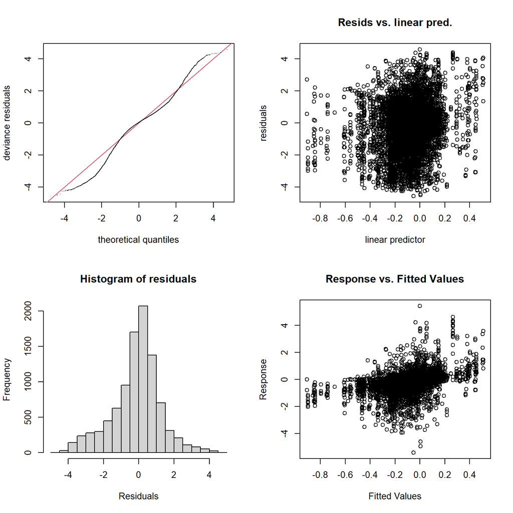

Figure 1: Residual diagnostics for the simple chest model (logdif_c). Panels show (clockwise from top-left): QQ plot of deviance residuals, residuals vs. linear predictor, histogram of residuals, and response vs. fitted values. The model was fitted with a scaled Student-t residual distribution.

```r
par(mfrow = c(2, 2))
gam.check(m1_logdif_c)
```

```
Method: fREML   Optimizer: perf newton
full convergence after 11 iterations.
Gradient range [-1.240905e-06,1.474164e-06]
(score 7964.537 & scale 1).
Hessian positive definite, eigenvalue range [1.090293,143.2699].
Model rank =  768 / 768

Basis dimension (k) checking results. Low p-value (k-index<1) may
indicate that k is too low, especially if edf is close to k'.

              k'    edf k-index p-value
s(site)     7.00   3.14      NA      NA
s(Id)      90.00  71.76      NA      NA
s(Id_day) 667.00 418.23      NA      NA
```

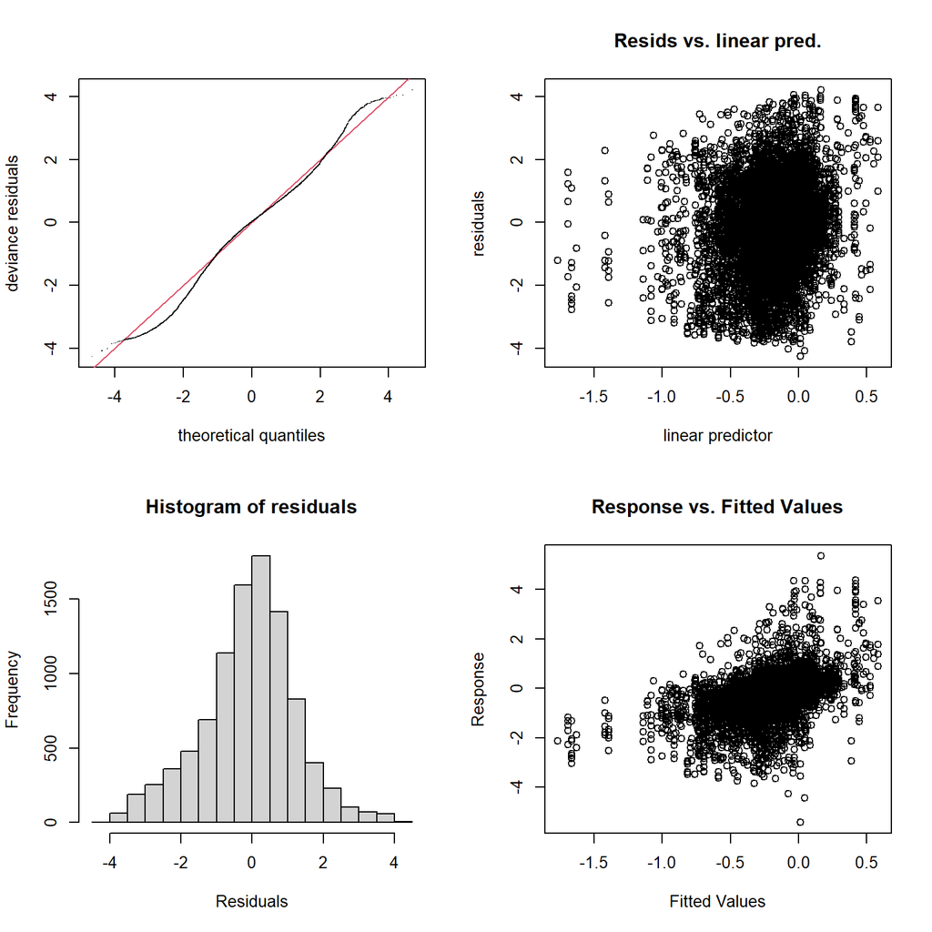

Figure 2: Residual diagnostics for the simple wrist model (logdif_w). Panels show (clockwise from top-left): QQ plot of deviance residuals, residuals vs. linear predictor, histogram of residuals, and response vs. fitted values. The model was fitted with a scaled Student-t residual distribution.

```r
par(mfrow = c(2, 2))
gam.check(m1_logdif_w)
```

The residual diagnostics for both models are shown in Figures Figure 1 and Figure 2. The following observations can be made regarding the plots in these figures:

- The QQ plots for both models look similar, though the chest appears less well matched. The center of the residual distribution fairly closely follows the reference line, indicating that the model’s mean structure is adequate. In the tails, the residuals deviate from the reference line (though with a somewhat limited magnitude and symmetrically), indicating that the observed residuals are somewhat heavier-tailed than the fitted scat(ν = 3) distribution. This could be a consequence of ν = 3 being the lower bound of the scat() family, meaning the model cannot represent heavier tails, even when the data may require them.
- In the residuals vs. linear predictions plot, the spread of residuals is fairly uniform across the range of fitted values. However, a slight funnel shape is visible, which could indicate mild heteroscedasticity.
- Both histograms of residuals confirm the model family choice, as the residuals appear to approximate a Student-t distribution.
- In the response vs. fitted values plots, there appears to be some structure, as the variability in responses increases for higher fitted values.

> **TBD: So the model fit clearly has some limitations. The question is whether the current fit is still valid to do an analysis of population-level means for each context. I’ve discussed this with a colleague who has more experience with statistics and looked for GAM diagnostics interpretation in literature. The bottom line is that my experience with GAM models is limited, so while I can find arguments for why these models can still be adequate for generating such mean estimates, I cannot fully judge whether these arguments are strong/well reasoned. So I think it is important to discuss this during our meeting, and I’m very curious about your thoughts!**

### **Detailed model: activity* photoperiod**

```r
# Chest model (logdif_c)
# m2_logdif_c <- bam(
#   logdif_c ~ act_context * photoperiod.state +
#     s(site, bs = "re") +
#     s(Id, bs = "re") +
#     s(Id_day, bs = "re"),
#   data   = ALL_hcw_hourly,
#   family = scat(),
#   method = "fREML"
# )
#
# saveRDS(m2_logdif_c, file = here("models", "m2_logdif_c.rds"))

m2_logdif_c <- readRDS(here("models", "m2_logdif_c.rds"))


# Wrist model (logdif_w)
# m2_logdif_w <- bam(
#   logdif_w ~ act_context * photoperiod.state +
#     s(site, bs = "re") +
#     s(Id, bs = "re") +
#     s(Id_day, bs = "re"),
#   data   = ALL_hcw_hourly,
#   family = scat(),
#   method = "fREML"
# )
#
# saveRDS(m2_logdif_w, file = here("models", "m2_logdif_w.rds"))

m2_logdif_w <- readRDS(here("models", "m2_logdif_w.rds"))
```

```r
summary(m2_logdif_c)
```

```
Family: Scaled t(3,0.226)
Link function: identity

Formula:
logdif_c ~ act_context * photoperiod.state + s(site, bs = "re") +
    s(Id, bs = "re") + s(Id_day, bs = "re")

Parametric coefficients:
                                                  Estimate Std. Error t value
(Intercept)                                      -0.089536   0.016322  -5.486
act_contextworking_indoor                         0.008409   0.008774   0.958
act_contextroad_vehicle                           0.109153   0.014684   7.433
act_contextoutdoor_act                            0.035975   0.011949   3.011
photoperiod.statenight                           -0.003036   0.009988  -0.304
act_contextworking_indoor:photoperiod.statenight -0.029472   0.019470  -1.514
act_contextroad_vehicle:photoperiod.statenight   -0.044330   0.033057  -1.341
act_contextoutdoor_act:photoperiod.statenight    -0.021015   0.027918  -0.753
                                                 Pr(>|t|)
(Intercept)                                      4.24e-08 ***
act_contextworking_indoor                         0.33786
act_contextroad_vehicle                          1.16e-13 ***
act_contextoutdoor_act                            0.00262 **
photoperiod.statenight                            0.76119
act_contextworking_indoor:photoperiod.statenight  0.13013
act_contextroad_vehicle:photoperiod.statenight    0.17995
act_contextoutdoor_act:photoperiod.statenight     0.45163
---
Signif. codes:  0 '***' 0.001 '**' 0.01 '*' 0.05 '.' 0.1 ' ' 1

Approximate significance of smooth terms:
              edf Ref.df      F p-value
s(site)     0.732      6  9.629   0.312
s(Id)      73.297     89 62.742  <2e-16 ***
s(Id_day) 417.045    664  3.374  <2e-16 ***
---
Signif. codes:  0 '***' 0.001 '**' 0.01 '*' 0.05 '.' 0.1 ' ' 1

R-sq.(adj) =  0.0959   Deviance explained = 14.2%
fREML = 4925.9  Scale est. = 1         n = 8876
```

```r
summary(m2_logdif_w)
```

```
Family: Scaled t(3,0.316)
Link function: identity

Formula:
logdif_w ~ act_context * photoperiod.state + s(site, bs = "re") +
    s(Id, bs = "re") + s(Id_day, bs = "re")

Parametric coefficients:
                                                 Estimate Std. Error t value
(Intercept)                                      -0.19211    0.03709  -5.180
act_contextworking_indoor                         0.02638    0.01239   2.129
act_contextroad_vehicle                           0.07516    0.02063   3.643
act_contextoutdoor_act                            0.04460    0.01681   2.653
photoperiod.statenight                           -0.03454    0.01403  -2.461
act_contextworking_indoor:photoperiod.statenight -0.02547    0.02736  -0.931
act_contextroad_vehicle:photoperiod.statenight   -0.03832    0.04637  -0.826
act_contextoutdoor_act:photoperiod.statenight    -0.14749    0.03921  -3.762
                                                 Pr(>|t|)
(Intercept)                                      2.27e-07 ***
act_contextworking_indoor                        0.033243 *
act_contextroad_vehicle                          0.000271 ***
act_contextoutdoor_act                           0.007994 **
photoperiod.statenight                           0.013860 *
act_contextworking_indoor:photoperiod.statenight 0.351816
act_contextroad_vehicle:photoperiod.statenight   0.408591
act_contextoutdoor_act:photoperiod.statenight    0.000170 ***
---
Signif. codes:  0 '***' 0.001 '**' 0.01 '*' 0.05 '.' 0.1 ' ' 1

Approximate significance of smooth terms:
              edf Ref.df       F  p-value
s(site)     3.689      6 784.549   0.0123 *
s(Id)      70.484     89  96.711 1.48e-05 ***
s(Id_day) 443.550    664   4.966  < 2e-16 ***
---
Signif. codes:  0 '***' 0.001 '**' 0.01 '*' 0.05 '.' 0.1 ' ' 1

R-sq.(adj) =  0.184   Deviance explained =   18%
fREML = 7210.7  Scale est. = 1         n = 8876
```

Both models converged successfully with a Student-t residual distribution (chest: ν = 3, σ = 0.226; wrist: ν = 3, σ = 0.316). As with the simple model, the estimated degrees of freedom reached the lower bound of the scat() family (ν = 3), indicating residuals at least as heavy-tailed as a t₃ distribution.

As in the simple model, the estimated random-effects structures differed between the two models. Site-level variance was estimated to be approximately zero in the chest model, whereas the wrist model indicated some site-specific variation. Participant-level and day-level random effects were substantial in both models, indicating considerable between-participant and within-participant day-to-day variability.

Deviance for the chest model was 14.2% and for the wrist model 18%, both slightly higher than for the simple models.

```
Method: fREML   Optimizer: perf newton
full convergence after 10 iterations.
Gradient range [-1.03157e-06,-9.416513e-08]
(score 4925.883 & scale 1).
Hessian positive definite, eigenvalue range [0.04967733,144.3248].
Model rank =  770 / 770

Basis dimension (k) checking results. Low p-value (k-index<1) may
indicate that k is too low, especially if edf is close to k'.

               k'     edf k-index p-value
s(site)     7.000   0.732      NA      NA
s(Id)      90.000  73.297      NA      NA
s(Id_day) 665.000 417.045      NA      NA
```

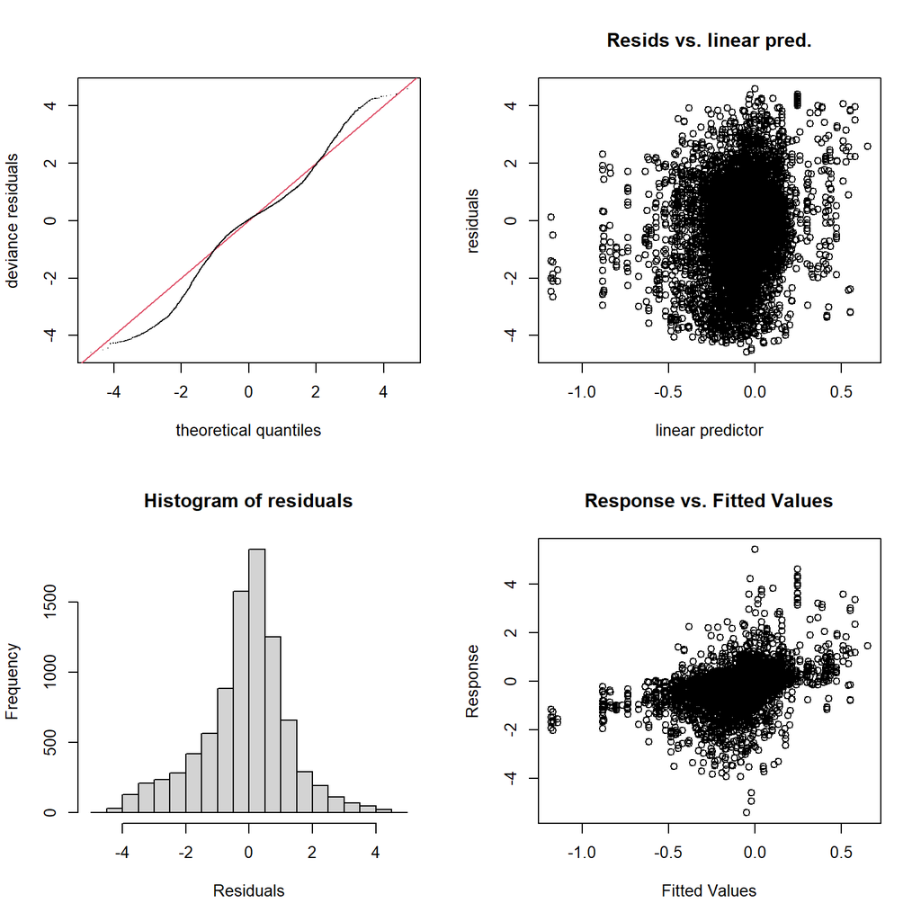

Figure 3: Residual diagnostics for the detailed chest model (logdif_c). Panels show (clockwise from top-left): QQ plot of deviance residuals, residuals vs. linear predictor, histogram of residuals, and response vs. fitted values. The model was fitted with a scaled Student-t residual distribution.

```r
par(mfrow = c(2, 2))
gam.check(m2_logdif_c)
```

```
Method: fREML   Optimizer: perf newton
full convergence after 7 iterations.
Gradient range [-1.863163e-06,3.479503e-06]
(score 7210.653 & scale 1).
Hessian positive definite, eigenvalue range [1.439028,159.2176].
Model rank =  770 / 770

Basis dimension (k) checking results. Low p-value (k-index<1) may
indicate that k is too low, especially if edf is close to k'.

              k'    edf k-index p-value
s(site)     7.00   3.69      NA      NA
s(Id)      90.00  70.48      NA      NA
s(Id_day) 665.00 443.55      NA      NA
```

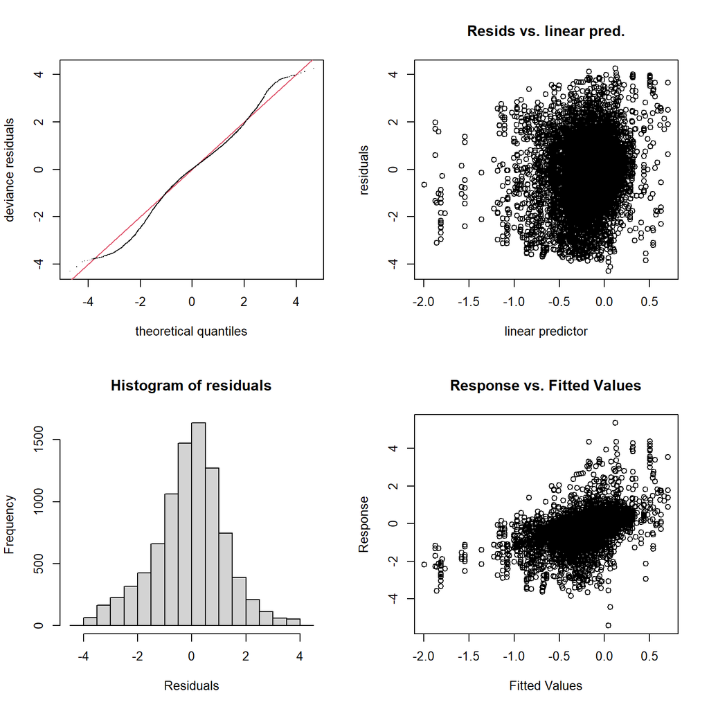

Figure 4: Residual diagnostics for the detailed wrist model (logdif_w). Panels show (clockwise from top-left): QQ plot of deviance residuals, residuals vs. linear predictor, histogram of residuals, and response vs. fitted values. The model was fitted with a scaled Student-t residual distribution.

```r
par(mfrow = c(2, 2))
gam.check(m2_logdif_w)
```

> **TBD: Similar limitations as for the simple model are present in the model diagnostics of the detailed model.**

### **Indoor lighting model: indoor work lighting contexts**

```r
# Chest model (logdif_c)
# m3_logdif_c <- bam(
#   logdif_c ~ light_context +
#     s(site, bs = "re") +
#     s(Id, bs = "re") +
#     s(Id_day, bs = "re"),
#   data   = ALL_hcw_hourly_indoor_work,
#   family = scat(),
#   method = "fREML"
# )
#
# saveRDS(m3_logdif_c, file = here("models", "m3_logdif_c.rds"))

m3_logdif_c <- readRDS(here("models", "m3_logdif_c.rds"))


# Wrist model (logdif_w)
# m3_logdif_w <- bam(
#   logdif_w ~ light_context +
#     s(site, bs = "re") +
#     s(Id, bs = "re") +
#     s(Id_day, bs = "re"),
#   data   = ALL_hcw_hourly_indoor_work,
#   family = scat(),
#   method = "fREML"
# )
#
# saveRDS(m3_logdif_w, file = here("models", "m3_logdif_w.rds"))

m3_logdif_w <- readRDS(here("models", "m3_logdif_w.rds"))
```

```r
summary(m3_logdif_c)
```

```
Family: Scaled t(3,0.156)
Link function: identity

Formula:
logdif_c ~ light_context + s(site, bs = "re") + s(Id, bs = "re") +
    s(Id_day, bs = "re")

Parametric coefficients:
                      Estimate Std. Error t value Pr(>|t|)
(Intercept)           -0.05208    0.01234  -4.220 2.51e-05 ***
light_contextdaylight -0.01958    0.01089  -1.798  0.07229 .
light_contextdisplay  -0.05823    0.02052  -2.838  0.00457 **
---
Signif. codes:  0 '***' 0.001 '**' 0.01 '*' 0.05 '.' 0.1 ' ' 1

Approximate significance of smooth terms:
                edf Ref.df      F p-value
s(site)   2.057e-04      6  0.000   0.518
s(Id)     6.072e+01     87 21.280  <2e-16 ***
s(Id_day) 2.560e+02    476  2.419  <2e-16 ***
---
Signif. codes:  0 '***' 0.001 '**' 0.01 '*' 0.05 '.' 0.1 ' ' 1

R-sq.(adj) =  0.0353   Deviance explained = 18.5%
fREML = 1028.4  Scale est. = 1         n = 3243
```

```r
summary(m3_logdif_w)
```

```
Family: Scaled t(3,0.238)
Link function: identity

Formula:
logdif_w ~ light_context + s(site, bs = "re") + s(Id, bs = "re") +
    s(Id_day, bs = "re")

Parametric coefficients:
                       Estimate Std. Error t value Pr(>|t|)
(Intercept)           -0.212874   0.049293  -4.319 1.62e-05 ***
light_contextdaylight  0.007941   0.018970   0.419  0.67554
light_contextdisplay  -0.099628   0.036080  -2.761  0.00579 **
---
Signif. codes:  0 '***' 0.001 '**' 0.01 '*' 0.05 '.' 0.1 ' ' 1

Approximate significance of smooth terms:
              edf Ref.df       F p-value
s(site)     2.978      6 1209.09 0.03574 *
s(Id)      60.689     87  222.73 0.00036 ***
s(Id_day) 361.084    476   29.46 < 2e-16 ***
---
Signif. codes:  0 '***' 0.001 '**' 0.01 '*' 0.05 '.' 0.1 ' ' 1

R-sq.(adj) =  0.342   Deviance explained = 33.7%
fREML = 2267.2  Scale est. = 1         n = 3243
```

Both models converged successfully with a Student-t residual distribution (chest: ν = 3, σ = 0.156; wrist: ν = 3, σ = 0.238). As with the simple and detailed models, the estimated degrees of freedom reached the lower bound of the scat() family (ν = 3), indicating residuals at least as heavy-tailed as a t₃ distribution.

Again, the estimated random-effects structures differed between the two models. Site-level variance was estimated to be low in the chest model, whereas the wrist model indicated some site-specific variation. Participant-level and day-level random effects were substantial in both models, indicating considerable between-participant and within-participant day-to-day variability.

Deviance for the chest model was 18.5% and for the wrist model 33.7%, both higher than for the simple and detailed models.

```
Method: fREML   Optimizer: perf newton
full convergence after 12 iterations.
Gradient range [-4.898645e-05,-1.502994e-05]
(score 1028.422 & scale 1).
Hessian positive definite, eigenvalue range [1.503325e-05,73.776].
Model rank =  575 / 575

Basis dimension (k) checking results. Low p-value (k-index<1) may
indicate that k is too low, especially if edf is close to k'.

                k'      edf k-index p-value
s(site)   7.00e+00 2.06e-04      NA      NA
s(Id)     8.80e+01 6.07e+01      NA      NA
s(Id_day) 4.77e+02 2.56e+02      NA      NA
```

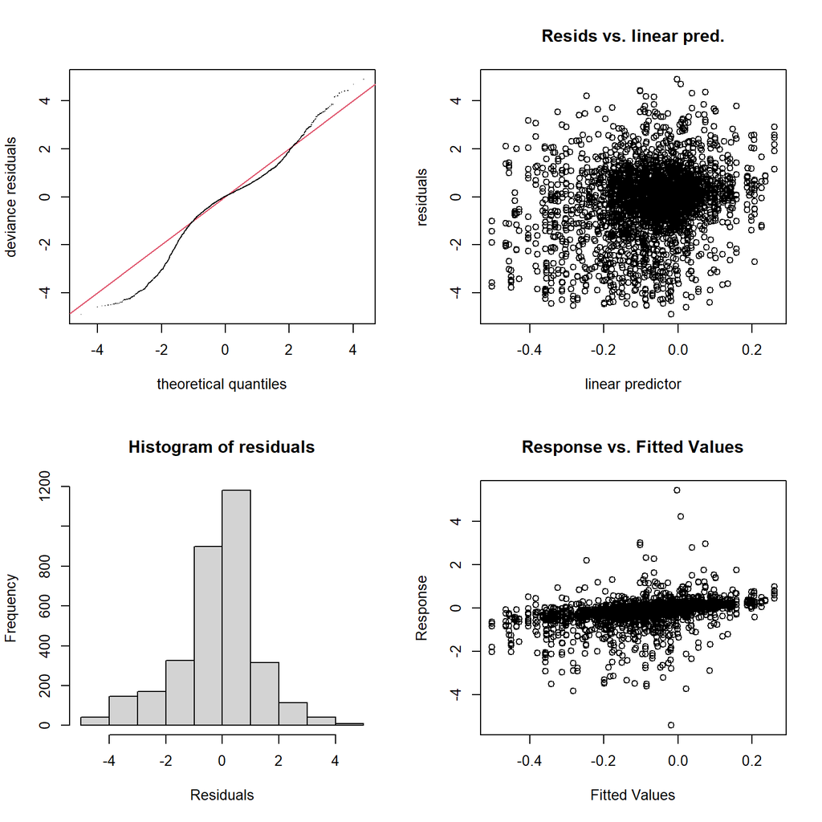

Figure 5: Residual diagnostics for the indoor lighting chest model (logdif_c). Panels show (clockwise from top-left): QQ plot of deviance residuals, residuals vs. linear predictor, histogram of residuals, and response vs. fitted values. The model was fitted with a scaled Student-t residual distribution.

```r
par(mfrow = c(2, 2))
gam.check(m3_logdif_c)
```

```
Method: fREML   Optimizer: perf newton
full convergence after 10 iterations.
Gradient range [-1.027172e-07,8.694158e-08]
(score 2267.176 & scale 1).
Hessian positive definite, eigenvalue range [0.9405753,147.0617].
Model rank =  575 / 575

Basis dimension (k) checking results. Low p-value (k-index<1) may
indicate that k is too low, especially if edf is close to k'.

              k'    edf k-index p-value
s(site)     7.00   2.98      NA      NA
s(Id)      88.00  60.69      NA      NA
s(Id_day) 477.00 361.08      NA      NA
```

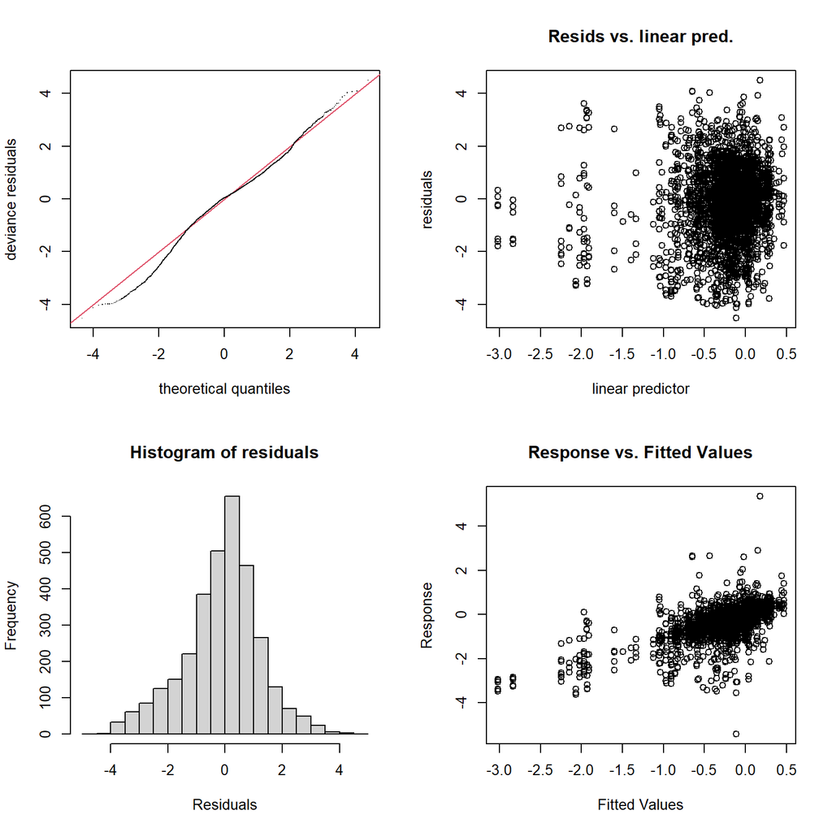

Figure 6: Residual diagnostics for the indoor lighting wrist model (logdif_w). Panels show (clockwise from top-left): QQ plot of deviance residuals, residuals vs. linear predictor, histogram of residuals, and response vs. fitted values. The model was fitted with a scaled Student-t residual distribution.

```r
par(mfrow = c(2, 2))
gam.check(m3_logdif_w)
```

For the chest model, the QQ plot shows asymmetry, with larger deviations from the reference line in the lower tail. This appears more problematic than for the simple and detailed models. In the residuals vs. linear predictions plot, the spread of residuals is fairly uniform across the range of fitted values. Both histograms of residuals confirm the model family choice, as the residuals appear to approximate a Student-t distribution. In the response vs. fitted values plots, responses increase with fitted values.

> **TBD: Limitations of the indoor lighting model fit diagnostics (especially the chest model).**

## Differences in eye-level and body-worn dosimeter measurements between contexts (comparative)

Subqestion 1 was formulated as: “Do mean log-transformed differences between eye-level and body-worn dosimeter measurements differ across contexts?”

Using the fitted models and the *emmeans* package (2.0.1), estimated marginal means of the log-transformed differences between eye-level and body-worn dosimeter measurements were computed for each combination of the fixed effects (contextual predictors). To identify if there are significant differences between the marginal means under each context, all combinations were compared using model-based t-tests (targeted contrasts). Confidence intervals and p-values were adjusted using Bonferroni correction (Jafari and Ansari-Pour 2018) to account for repeated testing.

### **Simple model: environment * photoperiod**

In the simple model there are only `environment` (*indoor* or *outdoor*) and `photoperiod.state` (*day* or *night*) as contextual factors. This results in four contrasts:

1. day * (indoor vs outdoor)
2. night * (indoor vs outdoor)
3. outdoor * (day vs night)
4. indoor * (day vs night)

```r
# Computing the estimated marginal means for each combination
emm_logdif_c <- emmeans(m1_logdif_c, ~ environment * photoperiod.state)
emm_logdif_w <- emmeans(m1_logdif_w, ~ environment * photoperiod.state)

# Specifying the Bonferroni correction
k <- 4  # number of contrasts per outcome
ci_level <- 1 - 0.05 / k  # = 0.9875

# Extract contrasts with manual Bonferroni adjustment
get_contrast_df <- function(emm_obj, by_var) {
  ct <- contrast(emm_obj, method = "pairwise", by = by_var)

  # Raw (unadjusted) summary
  ct_summary <- as.data.frame(summary(ct))

  # Bonferroni-adjusted CIs (widened to 98.75%)
  ct_ci <- as.data.frame(confint(ct, level = ci_level))

  ct_summary |>
    left_join(
      ct_ci |> select(all_of(c(by_var, "contrast", "lower.CL", "upper.CL"))),
      by = c(by_var, "contrast")
    ) |>
    # Manual Bonferroni adjustment of p-values
    mutate(p.value = pmin(p.value * k, 1))
}

# logdif_c results
env_photo_c_df <- get_contrast_df(emm_logdif_c, "photoperiod.state") |>
  mutate(outcome = "logdif_c", context = as.character(photoperiod.state))

photo_env_c_df <- get_contrast_df(emm_logdif_c, "environment") |>
  mutate(outcome = "logdif_c", context = as.character(environment))

# logdif_w results
env_photo_w_df <- get_contrast_df(emm_logdif_w, "photoperiod.state") |>
  mutate(outcome = "logdif_w", context = as.character(photoperiod.state))

photo_env_w_df <- get_contrast_df(emm_logdif_w, "environment") |>
  mutate(outcome = "logdif_w", context = as.character(environment))

# Combined table of results
contrast_table <- bind_rows(
  env_photo_c_df,
  photo_env_c_df,
  env_photo_w_df,
  photo_env_w_df
) |>
  mutate(
    estimate = round(estimate, 3),
    ci_low_95 = round(lower.CL, 3),
    ci_high_95 = round(upper.CL, 3),
    p.value = ifelse(p.value < 0.001, "<0.001", sprintf("%.3f", p.value))
  ) |>
  select(
    outcome,
    context,
    contrast,
    estimate,
    ci_low_95,
    ci_high_95,
    p.value
  )

contrast_table |>
  gt() |>
  cols_label(
    outcome = "Outcome",
    context = "Context",
    contrast = "Contrast",
    estimate = "Estimate",
    ci_low_95 = "CI low",
    ci_high_95 = "CI high",
    p.value = "p"
  ) |>
  tab_spanner(label = "95% CI", columns = c(ci_low_95, ci_high_95)) |>
  fmt_number(columns = c(estimate, ci_low_95, ci_high_95), decimals = 3)
```

Table 1: Estimates of contrasts between contextual factors in the simple model (environment * photoperiod). The estimates are based on the estimated marginal means of the log-transformed differences between body-worn and eye-level dosimeter measurements (logdif_c: chest-worn, logdif_w: wrist-worn). Each row compares two levels of one contextual factor while holding the other factor constant. Estimates are on the log₁₀ scale. Confidence intervals and p-values were adjusted (Bonferroni) for four within-outcome comparisons.

| Outcome | Context | Contrast | Estimate | 95% CI CI low | 95% CI CI high | p |  |
| --- | --- | --- | --- | --- | --- | --- | --- |
| logdif_c | day | outdoor - indoor | 0.058 | 0.035 | 0.080 |  | <0.001 |
| logdif_c | night | outdoor - indoor | 0.028 | −0.021 | 0.077 | 0.627 |  |
| logdif_c | outdoor | day - night | 0.036 | −0.014 | 0.086 | 0.275 |  |
| logdif_c | indoor | day - night | 0.007 | −0.012 | 0.025 | 1.000 |  |
| logdif_w | day | outdoor - indoor | 0.032 | 0.001 | 0.064 | 0.042 |  |
| logdif_w | night | outdoor - indoor | −0.073 | −0.143 | −0.004 | 0.034 |  |
| logdif_w | outdoor | day - night | 0.135 | 0.064 | 0.206 | <0.001 |  |
| logdif_w | indoor | day - night | 0.030 | 0.003 | 0.056 | 0.022 |  |

Because the mean log difference represents the magnitude of the systematic deviations between eye-level and body-worn dosimeter measurements, differences in the mean log difference across contexts indicate context dependence of these deviations. The differences are shown in Table 1. For chest-worn dosimeters, only one contrast was significant: the mean log difference differed between measurements in outdoor and indoor environments during daytime (0.058 log₁₀ m-EDI, p < 0.001). The other three contrasts were non-significant and small in absolute magnitude (difference estimate ≤ 0.036 log₁₀ m-EDI), indicating that the mean deviation between eye-level and chest-worn measurements is largely invariant across contexts. This does not imply the absence of deviations between both measurement positions, but rather that for chest‑worn dosimeters, the mean deviation shows little contextual dependence. In contrast, for wrist‑worn dosimeters, all tested contrasts were statistically significant, demonstrating that deviations from eye‑level measurements differ across contexts. Consequently, this indicates that contextual factors may be relevant when interpreting data from wrist‑worn dosimeters.

### **Detailed model: activity* photoperiod**

In the detailed model, the contextual factors are `act_context` (*home*, *working_indoor*, *road_vehicle*, or *outdoor_act*) and `photoperiod.state` (*day* or *night*). This results in the following combinations:

1. day * (home vs working_indoor)
2. day * (home vs road_vehicle)
3. day * (home vs outdoor_act)
4. day * (working_indoor vs road_vehicle)
5. day * (working_indoor vs outdoor_act)
6. day * (road_vehicle vs outdoor_act)
7. night * (home vs working_indoor)
8. night * (home vs road_vehicle)
9. night * (home vs outdoor_act)
10. night * (working_indoor vs road_vehicle)
11. night * (working_indoor vs outdoor_act)
12. night * (road_vehicle vs outdoor_act)
13. home * (day vs night)
14. working_indoor * (day vs night)
15. road_vehicle * (day vs night)
16. outdoor_act * (day vs night)

> **TBD: With 16 contrasts, the Bonferroni correction is very conservative. In my lecture notes, I found that generally for more than 5 comparisons a Tukeys range test is most appropriate. I also did the analysis below using a Tukeys range test, but that resulted in the same number of significant contrasts.**

```r
# Computing the estimated marginal means for each combination
emm_logdif_c <- emmeans(m2_logdif_c, ~ act_context * photoperiod.state)
emm_logdif_w <- emmeans(m2_logdif_w, ~ act_context * photoperiod.state)

# Specifying the Bonferroni correction
# 6 act_context pairwise within each photoperiod (×2) +
# 4 photoperiod within each act_context = 16
k <- 16
ci_level <- 1 - 0.05 / k  # = 0.996875

# Extract contrasts with manual Bonferroni adjustment
get_contrast_df <- function(emm_obj, by_var) {
  ct <- contrast(emm_obj, method = "pairwise", by = by_var)

  # Raw (unadjusted) summary
  ct_summary <- as.data.frame(summary(ct))

  # Bonferroni-adjusted CIs
  ct_ci <- as.data.frame(confint(ct, level = ci_level))

  ct_summary |>
    left_join(
      ct_ci |> select(all_of(c(by_var, "contrast", "lower.CL", "upper.CL"))),
      by = c(by_var, "contrast")
    ) |>
    # Manual Bonferroni adjustment of p-values
    mutate(p.value = pmin(p.value * k, 1))
}

# logdif_c results
act_photo_c_df <- get_contrast_df(emm_logdif_c, "photoperiod.state") |>
  mutate(outcome = "logdif_c", context = as.character(photoperiod.state))

photo_act_c_df <- get_contrast_df(emm_logdif_c, "act_context") |>
  mutate(outcome = "logdif_c", context = as.character(act_context))

# logdif_w results
act_photo_w_df <- get_contrast_df(emm_logdif_w, "photoperiod.state") |>
  mutate(outcome = "logdif_w", context = as.character(photoperiod.state))

photo_act_w_df <- get_contrast_df(emm_logdif_w, "act_context") |>
  mutate(outcome = "logdif_w", context = as.character(act_context))

# Combined table of results
contrast_table <- bind_rows(
  act_photo_c_df,
  photo_act_c_df,
  act_photo_w_df,
  photo_act_w_df
) |>
  mutate(
    estimate   = round(estimate, 3),
    ci_low_95  = round(lower.CL, 3),
    ci_high_95 = round(upper.CL, 3),
    p.value    = ifelse(p.value < 0.001, "<0.001", sprintf("%.3f", p.value))
  ) |>
  select(
    outcome,
    context,
    contrast,
    estimate,
    ci_low_95,
    ci_high_95,
    p.value
  )

contrast_table |>
  gt() |>
  cols_label(
    outcome = "Outcome",
    context = "Context",
    contrast = "Contrast",
    estimate = "Estimate",
    ci_low_95 = "CI low",
    ci_high_95 = "CI high",
    p.value = "p"
  ) |>
  tab_spanner(label = "95% CI", columns = c(ci_low_95, ci_high_95)) |>
  fmt_number(columns = c(estimate, ci_low_95, ci_high_95), decimals = 3)
```

Table 2: Estimates of contrasts between contextual factors in the detailed model (act_context * photoperiod). The estimates are based on the estimated marginal means of the log-transformed differences between body-worn and eye-level dosimeter measurements (logdif_c: chest-worn, logdif_w: wrist-worn). Each row compares two levels of one contextual factor while holding the other factor constant. Estimates are on the log₁₀ scale. Confidence intervals and p-values were adjusted (Bonferroni) for sixteen within-outcome comparisons.

| Outcome | Context | Contrast | Estimate | 95% CI CI low | 95% CI CI high | p |  |
| --- | --- | --- | --- | --- | --- | --- | --- |
| logdif_c | day | home - working_indoor | −0.008 | −0.039 | 0.022 |  | 1.000 |
| logdif_c | day | home - road_vehicle | −0.109 | −0.160 | −0.058 | <0.001 |  |
| logdif_c | day | home - outdoor_act | −0.036 | −0.077 | 0.005 | 0.223 |  |
| logdif_c | day | working_indoor - road_vehicle | −0.101 | −0.150 | −0.051 | <0.001 |  |
| logdif_c | day | working_indoor - outdoor_act | −0.028 | −0.069 | 0.013 | 1.000 |  |
| logdif_c | day | road_vehicle - outdoor_act | 0.073 | 0.016 | 0.131 | 0.001 |  |
| logdif_c | night | home - working_indoor | 0.021 | −0.041 | 0.083 | 1.000 |  |
| logdif_c | night | home - road_vehicle | −0.065 | −0.168 | 0.039 | 1.000 |  |
| logdif_c | night | home - outdoor_act | −0.015 | −0.104 | 0.074 | 1.000 |  |
| logdif_c | night | working_indoor - road_vehicle | −0.086 | −0.199 | 0.028 | 0.716 |  |
| logdif_c | night | working_indoor - outdoor_act | −0.036 | −0.135 | 0.063 | 1.000 |  |
| logdif_c | night | road_vehicle - outdoor_act | 0.050 | −0.080 | 0.180 | 1.000 |  |
| logdif_c | home | day - night | 0.003 | −0.026 | 0.033 | 1.000 |  |
| logdif_c | working_indoor | day - night | 0.033 | −0.017 | 0.082 | 0.800 |  |
| logdif_c | road_vehicle | day - night | 0.047 | −0.046 | 0.141 | 1.000 |  |
| logdif_c | outdoor_act | day - night | 0.024 | −0.053 | 0.101 | 1.000 |  |
| logdif_w | day | home - working_indoor | −0.026 | −0.069 | 0.016 | 1.000 |  |
| logdif_w | day | home - road_vehicle | −0.075 | −0.146 | −0.004 | 0.025 |  |
| logdif_w | day | home - outdoor_act | −0.045 | −0.103 | 0.013 | 0.639 |  |
| logdif_w | day | working_indoor - road_vehicle | −0.049 | −0.118 | 0.021 | 1.000 |  |
| logdif_w | day | working_indoor - outdoor_act | −0.018 | −0.076 | 0.039 | 1.000 |  |
| logdif_w | day | road_vehicle - outdoor_act | 0.031 | −0.050 | 0.112 | 1.000 |  |
| logdif_w | night | home - working_indoor | −0.001 | −0.088 | 0.086 | 1.000 |  |
| logdif_w | night | home - road_vehicle | −0.037 | −0.182 | 0.108 | 1.000 |  |
| logdif_w | night | home - outdoor_act | 0.103 | −0.022 | 0.228 | 0.367 |  |
| logdif_w | night | working_indoor - road_vehicle | −0.036 | −0.195 | 0.123 | 1.000 |  |
| logdif_w | night | working_indoor - outdoor_act | 0.104 | −0.036 | 0.243 | 0.795 |  |
| logdif_w | night | road_vehicle - outdoor_act | 0.140 | −0.043 | 0.322 | 0.653 |  |
| logdif_w | home | day - night | 0.035 | −0.007 | 0.076 | 0.222 |  |
| logdif_w | working_indoor | day - night | 0.060 | −0.009 | 0.129 | 0.160 |  |
| logdif_w | road_vehicle | day - night | 0.073 | −0.058 | 0.204 | 1.000 |  |
| logdif_w | outdoor_act | day - night | 0.182 | 0.074 | 0.291 | <0.001 |  |

For the chest, 3 out of 16 contrasts are significant (*home* - *road_vehicle*, *working_indoor* - *road_vehicle*, and *road_vehicle* - *outdoor_act*, all during the *day*) for the wrist 2 out of 16 (*home* - road *vehicle* during the *day* and *day* - *night* while doing an *outdoor_act*). Hence, the results from the detailed model indicate that there generally is no strong impact of contextual factors on the mean log-transformed differences between body-worn and eye-level dosimeter measurements.

**TBD: If no p-value correction is applied, then still only 6/16 of the chest and 8/16 of the wrist contrasts would have been significant. In the simple model, all wrist contrasts were significant. In the detailed model, it may be the case that categories are not different enough, e.g. *home* and *working_indoor* both describe indoor environments with (possibly) similar lighting. Moreover, in the detailed model, there are fewer observations available per category, resulting in larger confidence intervals. So, based on this, I think that with the available data resolution, only the simple model is appropriate.**

### **Indoor lighting model: indoor work lighting contexts**

In the indoor lighting model, the contextual factors are only `light_context` (*electric*, *daylight*, or *display*). This results in three combinations:

1. electric vs daylight
2. electric vs display
3. daylight vs display

```r
# Computing the estimated marginal means for each combination
emm_logdif_c <- emmeans(m3_logdif_c, ~ light_context)
emm_logdif_w <- emmeans(m3_logdif_w, ~ light_context)

# Specifying the Bonferroni correction
k <- 3  # C(3,2) pairwise contrasts
ci_level <- 1 - 0.05 / k  # 0.98333

# Extract contrasts with manual Bonferroni adjustment
get_contrast_df <- function(emm_obj) {
  ct <- contrast(emm_obj, method = "pairwise")

  ct_summary <- as.data.frame(summary(ct))
  ct_ci      <- as.data.frame(confint(ct, level = ci_level))

  ct_summary |>
    mutate(
      lower.CL = ct_ci$lower.CL,
      upper.CL = ct_ci$upper.CL,
      p.value  = pmin(p.value * k, 1)
    )
}

# logdif_c and logdif_w results
ct_c <- get_contrast_df(emm_logdif_c) |> mutate(outcome = "logdif_c")
ct_w <- get_contrast_df(emm_logdif_w) |> mutate(outcome = "logdif_w")

# Combined table of results
contrast_table <- bind_rows(ct_c, ct_w) |>
  mutate(
    estimate   = round(estimate, 3),
    ci_low_95  = round(lower.CL, 3),
    ci_high_95 = round(upper.CL, 3),
    p.value    = ifelse(p.value < 0.001, "<0.001", sprintf("%.3f", p.value))
  ) |>
  select(
    outcome,
    contrast,
    estimate,
    ci_low_95,
    ci_high_95,
    p.value
  )

contrast_table |>
  gt() |>
  cols_label(
    outcome    = "Outcome",
    contrast   = "Contrast",
    estimate   = "Estimate",
    ci_low_95  = "CI low",
    ci_high_95 = "CI high",
    p.value    = "p"
  ) |>
  tab_spanner(label = "95% CI", columns = c(ci_low_95, ci_high_95)) |>
  fmt_number(columns = c(estimate, ci_low_95, ci_high_95), decimals = 3)
```

Table 3: Estimates of contrasts between contextual factors in the indoor lighting model (light_context). The estimates are based on the estimated marginal means of the log-transformed differences between body-worn and eye-level dosimeter measurements (logdif_c: chest-worn, logdif_w: wrist-worn). Estimates are on the log₁₀ scale. Confidence intervals and p-values were adjusted (Bonferroni) for three within-outcome comparisons.

| Outcome | Contrast | Estimate | 95% CI CI low | 95% CI CI high | p |  |
| --- | --- | --- | --- | --- | --- | --- |
| logdif_c | electric - daylight | 0.020 | −0.010 | 0.049 |  | 0.511 |
| logdif_c | electric - display | 0.058 | 0.002 | 0.115 | 0.038 |  |
| logdif_c | daylight - display | 0.039 | −0.020 | 0.097 | 0.502 |  |
| logdif_w | electric - daylight | −0.008 | −0.060 | 0.044 | 1.000 |  |
| logdif_w | electric - display | 0.100 | 0.001 | 0.199 | 0.048 |  |
| logdif_w | daylight - display | 0.108 | 0.003 | 0.212 | 0.039 |  |

For chest-worn dosimeters, only the contrast between electric and display lighting was significant. For wrist-worn dosimeters, both the electric-display and daylight-display contrasts were significant. Hence, these results indicate that when considering hourly mean log-transformed differences between body-worn and eye-level dosimeter measurements in indoor work environments, the prevalent light source may impact these differences.

## Contextual differences in eye-level and body-worn dosimeter measurements (absolute)

Subqestion 2 was formulated as: “Under which contexts do the mean log-transformed differences between eye-level and body-worn dosimeter measurements differ significantly from zero?”

Each estimated marginal mean was tested against zero using model‑based t‑tests, where a value of zero corresponds to the eye-level and body-worn dosimeters measuring the same value. A negative estimate indicates that eye-level measurements were higher than body-worn measurements. For interpretability, estimates were back-transformed to multiplicative ratios of *MEDI + 0.1*. Note that because of the additive offset in the log transformation, these ratios slightly underestimate raw measurement ratios at very low light levels. Confidence intervals and p-values were adjusted using Bonferroni correction (Jafari and Ansari-Pour 2018) to account for repeated testing.

### **Simple model: environment * photoperiod**

```r
# Computing the estimated marginal means for each combination
emm_logdif_c <- emmeans(m1_logdif_c, ~ environment * photoperiod.state)
emm_logdif_w <- emmeans(m1_logdif_w, ~ environment * photoperiod.state)

# Bonferroni-adjusted test against zero + CIs
get_emm_table <- function(emm_obj) {
  # Adjusted p-values (test against zero)
  emm_test <- as.data.frame(test(emm_obj, null = 0, adjust = "bonferroni"))

  # Adjusted CIs
  emm_ci <- as.data.frame(confint(emm_obj, adjust = "bonferroni"))

  emm_test |>
    mutate(
      lower.CL = emm_ci$lower.CL,
      upper.CL = emm_ci$upper.CL
    )
}

# Get adjusted results
emm_c <- get_emm_table(emm_logdif_c) |> mutate(outcome = "logdif_c")
emm_w <- get_emm_table(emm_logdif_w) |> mutate(outcome = "logdif_w")

# Combined table of results
emm_ratio_table <- bind_rows(emm_c, emm_w) |>
  mutate(
    emmean_log = round(emmean, 3),

    # Back-transformed ratios using the Bonferroni-adjusted CIs
    ratio = round(10^emmean, 3),
    ratio_low_95 = round(10^lower.CL, 3),
    ratio_high_95 = round(10^upper.CL, 3),

    p.value = ifelse(p.value < 0.001, "<0.001", sprintf("%.3f", p.value))
  ) |>
  select(
    outcome,
    environment,
    photoperiod.state,
    emmean_log,
    ratio,
    ratio_low_95,
    ratio_high_95,
    p.value
  )

emm_ratio_table |>
  gt() |>
  cols_label(
    outcome = "Outcome",
    environment = "Environment",
    photoperiod.state = "Photoperiod",
    emmean_log = "Estimate (log)",
    ratio = "Estimate (ratio)",
    ratio_low_95  = "CI low (ratio)",
    ratio_high_95 = "CI high (ratio)",
    p.value    = "p"
  ) |>
  tab_spanner(label = "95% CI", columns = c(ratio_low_95, ratio_high_95)) |>
  fmt_number(columns = c(ratio, ratio_low_95, ratio_high_95), decimals = 2)
```

Table 4: Estimated marginal means of the log-transformed differences between body-worn and eye-level dosimeter measurements (logdif_c: chest, logdif_w: wrist) for contextual factors in the simple model (environment * photoperiod). Each combination was tested against zero. A value of zero corresponds to both dosimeters measuring the same value; a negative value indicates that eye-level measurements were higher than body-worn measurements. Confidence intervals and p-values were adjusted (Bonferroni) for four within-outcome comparisons.

| Outcome | Environment | Photoperiod | Estimate (log) | Estimate (ratio) | 95% CI CI low (ratio) | 95% CI CI high (ratio) | p |  |
| --- | --- | --- | --- | --- | --- | --- | --- | --- |
| logdif_c | outdoor | day | -0.025 | 0.94 | 0.86 | 1.03 |  | 0.453 |
| logdif_c | indoor | day | -0.082 | 0.83 | 0.76 | 0.90 | <0.001 |  |
| logdif_c | outdoor | night | -0.061 | 0.87 | 0.76 | 0.99 | 0.031 |  |
| logdif_c | indoor | night | -0.089 | 0.81 | 0.75 | 0.89 | <0.001 |  |
| logdif_w | outdoor | day | -0.142 | 0.72 | 0.60 | 0.86 | <0.001 |  |
| logdif_w | indoor | day | -0.174 | 0.67 | 0.56 | 0.80 | <0.001 |  |
| logdif_w | outdoor | night | -0.277 | 0.53 | 0.42 | 0.66 | <0.001 |  |
| logdif_w | indoor | night | -0.204 | 0.62 | 0.52 | 0.75 | <0.001 |  |

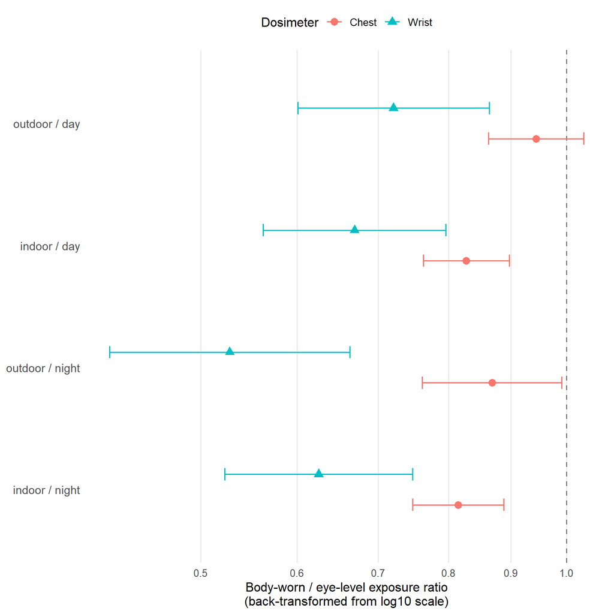

Figure 7: Estimated marginal means of the differences between eye-level and body-worn dosimeter measurements for contextual factors in the simple model (environment * photoperiod). Points represent the ratio of body-worn to eye-level measurements (ratio = 1 indicates equal measurements, shown by the dashed line). Horizontal bars indicate 95% confidence intervals (Bonferroni adjusted for four within-outcome comparisons). The x-axis is on a logarithmic scale, with labels shown as untransformed ratios. Intervals that do not cross the dashed line correspond to contexts in which body-worn dosimeter measurements differed significantly from those at eye-level. The wider confidence intervals for outdoor/night reflects the smaller sample size in this context.

```r
# Computing the estimated marginal means for each combination
emm_logdif_c <- emmeans(m1_logdif_c, ~ environment * photoperiod.state)
emm_logdif_w <- emmeans(m1_logdif_w, ~ environment * photoperiod.state)

# Prepare plot data with Bonferroni-adjusted CIs
plot_data <- bind_rows(
  as.data.frame(confint(emm_logdif_c, adjust = "bonferroni")) |>
    mutate(outcome = "Chest"),
  as.data.frame(confint(emm_logdif_w, adjust = "bonferroni")) |>
    mutate(outcome = "Wrist")
) |>
  mutate(
    ratio         = 10^emmean,
    ratio_low_95  = 10^lower.CL,
    ratio_high_95 = 10^upper.CL,
    context = paste(environment, photoperiod.state, sep = " / "),
    context = factor(
      context,
      levels = rev(c("outdoor / day",
                     "indoor / day",
                     "outdoor / night",
                     "indoor / night"))),
    outcome = factor(outcome, levels = c("Chest", "Wrist")))

# Forest plot
ggplot(plot_data, aes(x = ratio, y = context, colour = outcome, shape = outcome)) +
  geom_vline(xintercept = 1,
             linetype = "dashed",
             colour = "grey50") +
  geom_errorbar(aes(xmin = ratio_low_95,
                    xmax = ratio_high_95),
                orientation = "y",
                width = 0.2,
                position = position_dodge(width = 0.5)) +
  geom_point(size = 3,
             position = position_dodge(width = 0.5)) +
  scale_x_log10(
    breaks = c(0.4, 0.5, 0.6, 0.7, 0.8, 0.9, 1.0, 1.1),
    labels = c("0.4", "0.5", "0.6", "0.7", "0.8", "0.9", "1.0", "1.1")
  ) +
  labs(
    x = "Body-worn / eye-level exposure ratio\n(back-transformed from log10 scale)",
    y = NULL,
    colour = "Dosimeter",
    shape  = "Dosimeter",
    title  = NULL
  ) +
  theme_minimal(base_size = 12) +
  theme(
    panel.grid.major.y = element_blank(),
    panel.grid.minor   = element_blank(),
    legend.position    = "top",
    axis.text.y        = element_text(size = 11)
  )
```

### **Detailed model: activity* photoperiod**

```r
# Computing the estimated marginal means for each combination
emm_logdif_c <- emmeans(m2_logdif_c, ~ act_context  * photoperiod.state)
emm_logdif_w <- emmeans(m2_logdif_w, ~ act_context  * photoperiod.state)

# Bonferroni-adjusted test against zero + CIs
# With 4 act_context levels × 2 photoperiod levels = 8 cells per outcome
# emmeans handles k = 8 correctly here since all 8 EMMs are in a single object
get_emm_table <- function(emm_obj) {
  # Adjusted p-values (test against zero)
  emm_test <- as.data.frame(test(emm_obj, null = 0, adjust = "bonferroni"))

  # Adjusted CIs
  emm_ci <- as.data.frame(confint(emm_obj, adjust = "bonferroni"))

  emm_test |>
    mutate(
      lower.CL = emm_ci$lower.CL,
      upper.CL = emm_ci$upper.CL
    )
}

# Get adjusted results
emm_c <- get_emm_table(emm_logdif_c) |> mutate(outcome = "logdif_c")
emm_w <- get_emm_table(emm_logdif_w) |> mutate(outcome = "logdif_w")

# Combined table of results
emm_ratio_table <- bind_rows(emm_c, emm_w) |>
  mutate(
    emmean_log = round(emmean, 3),

    # Back-transformed ratios using the Bonferroni-adjusted CIs
    ratio = round(10^emmean, 3),
    ratio_low_95 = round(10^lower.CL, 3),
    ratio_high_95 = round(10^upper.CL, 3),

    p.value = ifelse(p.value < 0.001, "<0.001", sprintf("%.3f", p.value))
  ) |>
  select(
    outcome,
    act_context,
    photoperiod.state,
    emmean_log,
    ratio,
    ratio_low_95,
    ratio_high_95,
    p.value
  )

emm_ratio_table |>
  gt() |>
  cols_label(
    outcome = "Outcome",
    act_context = "Activity",
    photoperiod.state = "Photoperiod",
    emmean_log = "Estimate (log)",
    ratio = "Estimate (ratio)",
    ratio_low_95  = "CI low (ratio)",
    ratio_high_95 = "CI high (ratio)",
    p.value    = "p"
  ) |>
  tab_spanner(label = "95% CI", columns = c(ratio_low_95, ratio_high_95)) |>
  fmt_number(columns = c(ratio, ratio_low_95, ratio_high_95), decimals = 2)
```

Table 5: Estimated marginal means of the log-transformed differences between body-worn and eye-level dosimeter measurements (logdif_c: chest, logdif_w: wrist) for contextual factors in the detailed model (activity * photoperiod). Each combination was tested against zero. A value of zero corresponds to both dosimeters measuring the same value; a negative value indicates that eye-level measurements were higher than body-worn measurements. Confidence intervals and p-values were adjusted (Bonferroni) for eight within-outcome comparisons.

| Outcome | Activity | Photoperiod | Estimate (log) | Estimate (ratio) | 95% CI CI low (ratio) | 95% CI CI high (ratio) | p |  |
| --- | --- | --- | --- | --- | --- | --- | --- | --- |
| logdif_c | home | day | -0.090 | 0.81 | 0.73 | 0.90 |  | <0.001 |
| logdif_c | working_indoor | day | -0.081 | 0.83 | 0.75 | 0.92 | <0.001 |  |
| logdif_c | road_vehicle | day | 0.020 | 1.05 | 0.92 | 1.19 | 1.000 |  |
| logdif_c | outdoor_act | day | -0.054 | 0.88 | 0.79 | 0.99 | 0.027 |  |
| logdif_c | home | night | -0.093 | 0.81 | 0.73 | 0.90 | <0.001 |  |
| logdif_c | working_indoor | night | -0.114 | 0.77 | 0.67 | 0.88 | <0.001 |  |
| logdif_c | road_vehicle | night | -0.028 | 0.94 | 0.76 | 1.15 | 1.000 |  |
| logdif_c | outdoor_act | night | -0.078 | 0.84 | 0.70 | 1.00 | 0.054 |  |
| logdif_w | home | day | -0.192 | 0.64 | 0.51 | 0.81 | <0.001 |  |
| logdif_w | working_indoor | day | -0.166 | 0.68 | 0.54 | 0.86 | <0.001 |  |
| logdif_w | road_vehicle | day | -0.117 | 0.76 | 0.59 | 0.99 | 0.032 |  |
| logdif_w | outdoor_act | day | -0.148 | 0.71 | 0.56 | 0.91 | 0.001 |  |
| logdif_w | home | night | -0.227 | 0.59 | 0.47 | 0.75 | <0.001 |  |
| logdif_w | working_indoor | night | -0.226 | 0.59 | 0.46 | 0.78 | <0.001 |  |
| logdif_w | road_vehicle | night | -0.190 | 0.65 | 0.46 | 0.91 | 0.004 |  |
| logdif_w | outdoor_act | night | -0.330 | 0.47 | 0.34 | 0.64 | <0.001 |  |

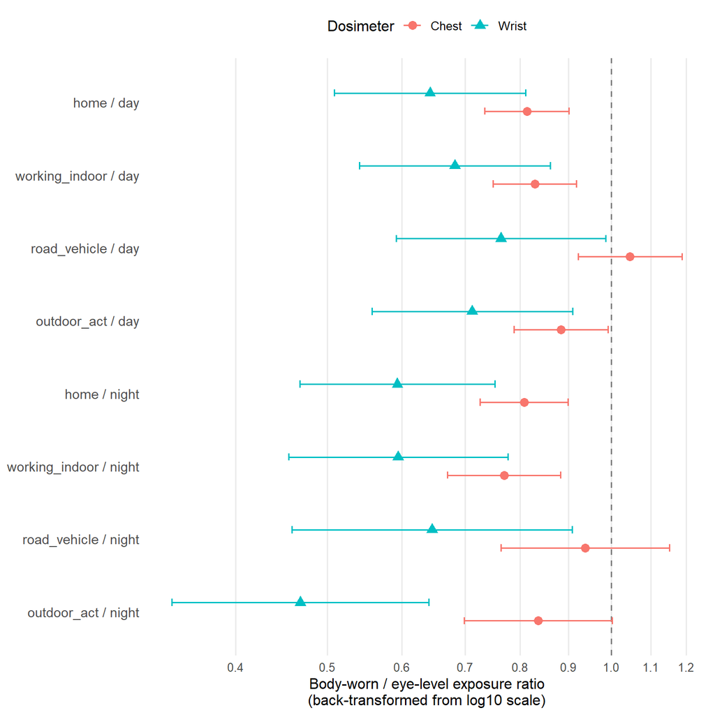

Figure 8: Estimated marginal means of the differences between eye-level and body-worn dosimeter measurements for contextual factors in the detailed model (activity * photoperiod). Points represent the ratio of body-worn to eye-level measurements (ratio = 1 indicates equal measurements, shown by the dashed line). Horizontal bars indicate 95% confidence intervals (Bonferroni adjusted for eight within-outcome comparisons). The x-axis is on a logarithmic scale, with labels shown as untransformed ratios. Intervals that do not cross the dashed line correspond to contexts in which body-worn dosimeter measurements differed significantly from those at eye-level.

```r
# Computing the estimated marginal means for each combination
emm_logdif_c <- emmeans(m2_logdif_c, ~ act_context * photoperiod.state)
emm_logdif_w <- emmeans(m2_logdif_w, ~ act_context * photoperiod.state)

# Prepare plot data with Bonferroni-adjusted CIs
plot_data <- bind_rows(
  as.data.frame(confint(emm_logdif_c, adjust = "bonferroni")) |>
    mutate(outcome = "Chest"),
  as.data.frame(confint(emm_logdif_w, adjust = "bonferroni")) |>
    mutate(outcome = "Wrist")
) |>
  mutate(
    ratio         = 10^emmean,
    ratio_low_95  = 10^lower.CL,
    ratio_high_95 = 10^upper.CL,
    context = paste(act_context, photoperiod.state, sep = " / "),
    context = factor(
      context,
      levels = rev(c("home / day",
                     "working_indoor / day",
                     "road_vehicle / day",
                     "outdoor_act / day",
                     "home / night",
                     "working_indoor / night",
                     "road_vehicle / night",
                     "outdoor_act / night"))),
    outcome = factor(outcome, levels = c("Chest", "Wrist")))

# Forest plot
ggplot(plot_data, aes(x = ratio, y = context, colour = outcome, shape = outcome)) +
  geom_vline(xintercept = 1,
             linetype = "dashed",
             colour = "grey50") +
  geom_errorbar(aes(xmin = ratio_low_95,
                    xmax = ratio_high_95),
                orientation = "y",
                width = 0.2,
                position = position_dodge(width = 0.5)) +
  geom_point(size = 3,
             position = position_dodge(width = 0.5)) +
  scale_x_log10(
    breaks = c(0.3, 0.4, 0.5, 0.6, 0.7, 0.8, 0.9, 1.0, 1.1, 1.2),
    labels = c("0.3", "0.4", "0.5", "0.6", "0.7", "0.8", "0.9", "1.0", "1.1", "1.2")
  ) +
  labs(
    x = "Body-worn / eye-level exposure ratio\n(back-transformed from log10 scale)",
    y = NULL,
    colour = "Dosimeter",
    shape  = "Dosimeter",
    title  = NULL
  ) +
  theme_minimal(base_size = 12) +
  theme(
    panel.grid.major.y = element_blank(),
    panel.grid.minor   = element_blank(),
    legend.position    = "top",
    axis.text.y        = element_text(size = 11)
  )
```

The estimated marginal means are shown in Table 5 and Figure 8. For chest-worn dosimeters, no significant differences from eye-level measurements were present when being in a *road_vehicle* during the *day* and *night*, and when doing an *outdoor_act* during the *night*. For wrist-worn dosimeters, differences from eye-level measurements were significant under all contexts.

### **Indoor lighting model: indoor work lighting contexts**

```r
# Computing the estimated marginal means for each light context
emm_logdif_c <- emmeans(m3_logdif_c, ~ light_context)
emm_logdif_w <- emmeans(m3_logdif_w, ~ light_context)

# Bonferroni-adjusted test against zero + CIs
# With 3 light_context levels = 3 cells per outcome
# emmeans handles k = 3 correctly here since all 3 EMMs are in a single object
get_emm_table <- function(emm_obj) {
  # Adjusted p-values (test against zero)
  emm_test <- as.data.frame(test(emm_obj, null = 0, adjust = "bonferroni"))

  # Adjusted CIs
  emm_ci <- as.data.frame(confint(emm_obj, adjust = "bonferroni"))

  emm_test |>
    mutate(
      lower.CL = emm_ci$lower.CL,
      upper.CL = emm_ci$upper.CL
    )
}

# Get adjusted results
emm_c <- get_emm_table(emm_logdif_c) |> mutate(outcome = "logdif_c")
emm_w <- get_emm_table(emm_logdif_w) |> mutate(outcome = "logdif_w")

# Combined table of results
emm_ratio_table <- bind_rows(emm_c, emm_w) |>
  mutate(
    emmean_log = round(emmean, 3),

    # Back-transformed ratios using the Bonferroni-adjusted CIs
    ratio         = round(10^emmean, 3),
    ratio_low_95  = round(10^lower.CL, 3),
    ratio_high_95 = round(10^upper.CL, 3),

    p.value = ifelse(p.value < 0.001, "<0.001", sprintf("%.3f", p.value))
  ) |>
  select(
    outcome,
    light_context,
    emmean_log,
    ratio,
    ratio_low_95,
    ratio_high_95,
    p.value
  )

emm_ratio_table |>
  gt() |>
  cols_label(
    outcome       = "Outcome",
    light_context = "Light context",
    emmean_log    = "Estimate (log)",
    ratio         = "Estimate (ratio)",
    ratio_low_95  = "CI low (ratio)",
    ratio_high_95 = "CI high (ratio)",
    p.value       = "p"
  ) |>
  tab_spanner(label = "95% CI", columns = c(ratio_low_95, ratio_high_95)) |>
  fmt_number(columns = c(ratio, ratio_low_95, ratio_high_95), decimals = 2)
```

Table 6: Estimated marginal means of the log-transformed differences between body-worn and eye-level dosimeter measurements (logdif_c: chest, logdif_w: wrist) for contextual factors in the indoor lighting model (light_context). Each combination was tested against zero. A value of zero corresponds to both dosimeters measuring the same value; a negative value indicates that eye-level measurements were higher than body-worn measurements. Confidence intervals and p-values were adjusted (Bonferroni) for three within-outcome comparisons.

| Outcome | Light context | Estimate (log) | Estimate (ratio) | 95% CI CI low (ratio) | 95% CI CI high (ratio) | p |  |
| --- | --- | --- | --- | --- | --- | --- | --- |
| logdif_c | electric | -0.052 | 0.89 | 0.83 | 0.95 |  | <0.001 |
| logdif_c | daylight | -0.072 | 0.85 | 0.79 | 0.91 | <0.001 |  |
| logdif_c | display | -0.110 | 0.78 | 0.69 | 0.88 | <0.001 |  |
| logdif_w | electric | -0.213 | 0.61 | 0.47 | 0.80 | <0.001 |  |
| logdif_w | daylight | -0.205 | 0.62 | 0.47 | 0.82 | <0.001 |  |
| logdif_w | display | -0.313 | 0.49 | 0.35 | 0.67 | <0.001 |  |

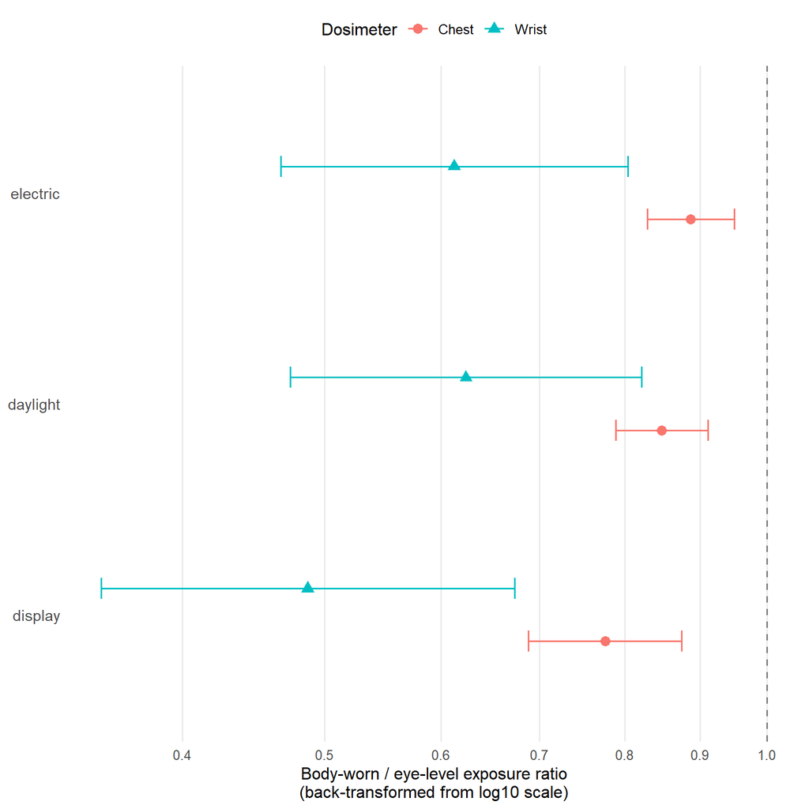

Figure 9: Estimated marginal means of the differences between eye-level and body-worn dosimeter measurements for contextual factors in the indoor lighting model (light_context). Points represent the ratio of body-worn to eye-level measurements (ratio = 1 indicates equal measurements, shown by the dashed line). Horizontal bars indicate 95% confidence intervals (Bonferroni adjusted for three within-outcome comparisons). The x-axis is on a logarithmic scale, with labels shown as untransformed ratios. Intervals that do not cross the dashed line correspond to contexts in which body-worn dosimeter measurements differed significantly from those at eye-level.

```r
# Computing the estimated marginal means for each combination
emm_logdif_c <- emmeans(m3_logdif_c, ~ light_context)
emm_logdif_w <- emmeans(m3_logdif_w, ~ light_context)

# Prepare plot data with Bonferroni-adjusted CIs
plot_data <- bind_rows(
  as.data.frame(confint(emm_logdif_c, adjust = "bonferroni")) |>
    mutate(outcome = "Chest"),
  as.data.frame(confint(emm_logdif_w, adjust = "bonferroni")) |>
    mutate(outcome = "Wrist")
) |>
  mutate(
    ratio         = 10^emmean,
    ratio_low_95  = 10^lower.CL,
    ratio_high_95 = 10^upper.CL,
    context = factor(
      light_context,
      levels = rev(c("electric", "daylight", "display"))
    ),
    outcome = factor(outcome, levels = c("Chest", "Wrist"))
  )

# Forest plot
ggplot(plot_data, aes(x = ratio, y = context, colour = outcome, shape = outcome)) +
  geom_vline(xintercept = 1,
             linetype = "dashed",
             colour = "grey50") +
  geom_errorbar(aes(xmin = ratio_low_95,
                    xmax = ratio_high_95),
                orientation = "y",
                width = 0.2,
                position = position_dodge(width = 0.5)) +
  geom_point(size = 3,
             position = position_dodge(width = 0.5)) +
  scale_x_log10(
    breaks = c(0.3, 0.4, 0.5, 0.6, 0.7, 0.8, 0.9, 1.0, 1.1, 1.2),
    labels = c("0.3", "0.4", "0.5", "0.6", "0.7", "0.8", "0.9", "1.0", "1.1", "1.2")
  ) +
  labs(
    x = "Body-worn / eye-level exposure ratio\n(back-transformed from log10 scale)",
    y = NULL,
    colour = "Dosimeter",
    shape  = "Dosimeter",
    title  = NULL
  ) +
  theme_minimal(base_size = 12) +
  theme(
    panel.grid.major.y = element_blank(),
    panel.grid.minor   = element_blank(),
    legend.position    = "top",
    axis.text.y        = element_text(size = 11)
  )
```

The estimated marginal means are shown in Table 6 and Figure 9. Across all indoor light sources in work environments, all differences between body-worn (chest or wrist) dosimeters and eye-level measurements were significant.

## Acknowledgments

Code and (text) formatting optimizations were conducted using Claude Opus 4.6 (Anthropic). All generated suggestions were reviewed and validated by the author, who takes full responsibility for the final code and results.

## References

Aerts, Sam, Astrid Astrid Jansen, Nico Hogervorst, Daan Boesten, John Bolte, Johannes Zauner, and Manuel Spitschan. 2025. *Personal Light Exposure Dataset for Delft, the Netherlands*. Zenodo. https://doi.org/10.5281/ZENODO.17979893.

Akuffo, Kwadwo Owusu, Gabriel Kwaku Agbeshie, Johannes Zauner, and Manuel Spitschan. 2025. *Personal Light Exposure Dataset for Kumasi, Ghana*. Zenodo. https://doi.org/10.5281/ZENODO.15576731.

Baeza Moyano, David, María Concepción Pérez Gutiérrez, Guadalupe Cantarero García, Roberto Alonso González Lezcano, Sofía Melero Tur, Johannes Zauner, and Manuel Spitschan. 2025. *Personal Light Exposure Dataset for Madrid, Spain*. Zenodo. https://doi.org/10.5281/ZENODO.16834951.

Broszio, Kai, Johannes Zauner, and Manuel Spitschan. 2025. *Personal Light Exposure Dataset for Dortmund, Germany*. Zenodo. https://doi.org/10.5281/ZENODO.18111232.

De Vries, S. W., J. Mardaljevic, and J van Duijnhoven. In press. “Impact of Wear Position on Dosimeter Performance: A Hybrid Measurement-Simulation Approach to Quantify in-Situ Factors.” *Npj Biological Timing and Sleep*, In press.

———. In press. “Impact of Wear Position on Dosimeter Performance: Measurement Reliability Under Simulated Indoor Illumination.” *Npj Biological Timing and Sleep*, In press.

Didikoglu, Altug, Sena Gulsum Akgun, Sema Nur Aydin, Zeynep Kayar, Johannes Zauner, and Manuel Spitschan. 2025. *Personal Light Exposure Dataset for Izmir, Türkiye*. Zenodo. https://doi.org/10.5281/ZENODO.16568109.

Guidolin, Carolina, Sam Aerts, Gabriel Kwaku Agbeshie, Kwadwo Owusu Akuffo, Sema Nur Aydin, David Baeza-Moyano, John Bolte, et al. 2024. “Protocol for a Prospective, Multicentre, Cross-Sectional Cohort Study to Assess Personal Light Exposure.” *BMC Public Health* 24 (1). https://doi.org/10.1186/s12889-024-20206-4.

Hilden, Sarina, Suyoun Lee, Johannes Zauner, and Manuel Spitschan. 2025. *Personal Light Exposure Dataset for Munich, Germany*. Zenodo. https://doi.org/10.5281/ZENODO.16893901.

Jafari, Mohieddin, and Naser Ansari-Pour. 2018. “Why, When and How to Adjust Your P Values?” *Cell Journal (Yakhteh)* 20 (4). https://doi.org/10.22074/cellj.2019.5992.

Nilsson Tengelin, Maria, Ingemar Svensson, Stefan Källberg, Johannes Zauner, and Manuel Spitschan. 2026. *Personal Light Exposure Dataset for Borås, Sweden*. Zenodo. https://doi.org/10.5281/ZENODO.18925834.

Sancho-Salas, Andrea, Helga von-Breymann, Johannes Zauner, and Manuel Spitschan. 2026. *Personal Light Exposure Dataset for San Pedro, San José, Costa Rica*. Zenodo. https://doi.org/10.5281/ZENODO.17289456.